# R Notebook

## Read the data tuno.txt into R.

The data is read, and the first few lines of the code is shown.

```r
data <- read.delim("tuno.txt",header = TRUE, sep = " ", dec = ".")
data$pow.obs.norm<-(data$pow.obs)/5000
head(data,6)
```

|  | r.day | month | day | pow.obs | ws30 | wd30 | pow.obs.norm |
| --- | --- | --- | --- | --- | --- | --- | --- |
| 1 | 1 | 1 | 1 | 243.0278 | 6.723611 | 4.0343405 | 0.04860556 |
| 2 | 2 | 1 | 2 | 2780.0137 | 4.272603 | 2.1365208 | 0.55600274 |
| 3 | 3 | 1 | 3 | 2118.6164 | 4.272603 | 1.6240318 | 0.42372329 |
| 4 | 4 | 1 | 4 | 1660.8767 | 6.541096 | 0.2269022 | 0.33217534 |
| 5 | 5 | 1 | 5 | 1872.7945 | 9.713699 | 5.3161852 | 0.37455890 |
| 6 | 6 | 1 | 6 | 3212.2603 | 8.161644 | 0.9522963 | 0.64245205 |

### 1. Formulate an initial model

The model that we consider is:
$$y=f(w_s)=\beta_0+\beta_1w_s+\beta_2w_s^2$$
Where y is the observed power production and f is a function of wind speed.

```r
mod1=lm(pow.obs.norm~ ws30+I(ws30^2), data=data)
summary(mod1)
```

```
Call:
lm(formula = pow.obs.norm ~ ws30 + I(ws30^2), data = data)

Residuals:
     Min       1Q   Median       3Q      Max
-0.47630 -0.10464 -0.02010  0.09463  0.65792

Coefficients:
              Estimate Std. Error t value Pr(>|t|)
(Intercept) -0.1857444  0.0399230  -4.653 5.03e-06 ***
ws30         0.0581438  0.0074991   7.753 1.59e-13 ***
I(ws30^2)   -0.0006536  0.0003086  -2.118    0.035 *
---
Signif. codes:  0 ‘***’ 0.001 ‘**’ 0.01 ‘*’ 0.05 ‘.’ 0.1 ‘ ’ 1

Residual standard error: 0.1648 on 285 degrees of freedom
Multiple R-squared:  0.5894,    Adjusted R-squared:  0.5866
F-statistic: 204.6 on 2 and 285 DF,  p-value: < 2.2e-16
```

```r
AIC(mod1)
```

```
[1] -216.3865
```

All parameters are significant.

```
[1] 59  2
```

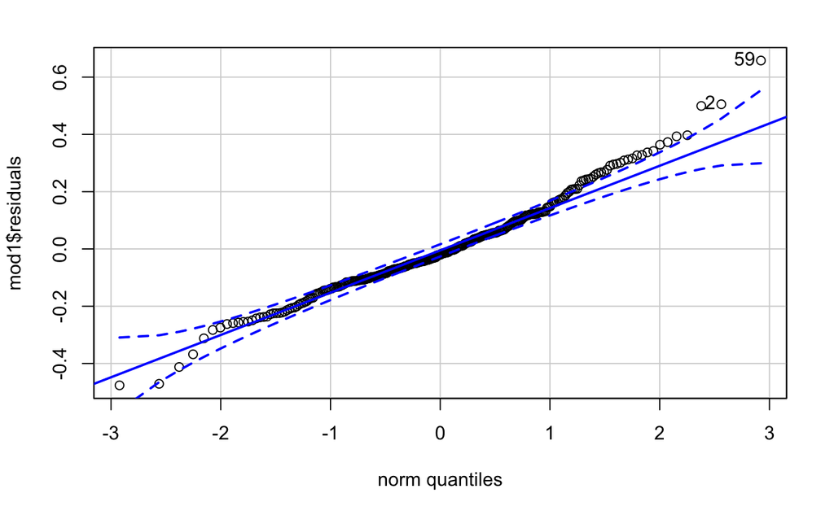

```r
library(car)
qqPlot(mod1$residuals)
```

### 2. You might consider non-normal models and/or normal model with data transformation. Further you might consider including wind direction. You should devellop a suited model for prediction of daily power produAction.

#### Models without tranformation

```r
mod2=glm(pow.obs.norm~ ws30,family=Gamma,  data=data)
summary(mod2)
```

```
Call:
glm(formula = pow.obs.norm ~ ws30, family = Gamma, data = data)

Deviance Residuals:
    Min       1Q   Median       3Q      Max
-3.9508  -1.1110  -0.1795   0.4959   1.8904

Coefficients:
            Estimate Std. Error t value Pr(>|t|)
(Intercept)  6.76236    0.36615   18.47   <2e-16 ***
ws30        -0.25487    0.01758  -14.49   <2e-16 ***
---
Signif. codes:  0 ‘***’ 0.001 ‘**’ 0.01 ‘*’ 0.05 ‘.’ 0.1 ‘ ’ 1

(Dispersion parameter for Gamma family taken to be 0.6994038)

    Null deviance: 503.32  on 287  degrees of freedom
Residual deviance: 419.34  on 286  degrees of freedom
AIC: -246.42

Number of Fisher Scoring iterations: 6
```

```r
AIC(mod2)
```

```
[1] -246.4242
```

```
[1] 59  2
```

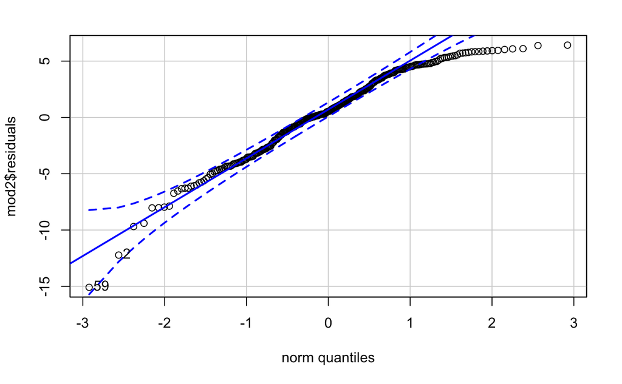

```r
qqPlot(mod2$residuals)
```

```r
library(betareg)
mod8=betareg(pow.obs.norm~ ws30, data=data)
summary(mod8)
```

```
Call:
betareg(formula = pow.obs.norm ~ ws30, data = data)

Standardized weighted residuals 2:
    Min      1Q  Median      3Q     Max
-4.4294 -0.4774  0.1123  0.6225  2.8911

Coefficients (mean model with logit link):
            Estimate Std. Error z value Pr(>|z|)
(Intercept) -3.14627    0.14302  -22.00   <2e-16 ***
ws30         0.22309    0.01299   17.18   <2e-16 ***

Phi coefficients (precision model with identity link):
      Estimate Std. Error z value Pr(>|z|)
(phi)   4.7813     0.3982   12.01   <2e-16 ***
---
Signif. codes:  0 '***' 0.001 '**' 0.01 '*' 0.05 '.' 0.1 ' ' 1

Type of estimator: ML (maximum likelihood)
Log-likelihood: 234.4 on 3 Df
Pseudo R-squared: 0.4668
Number of iterations: 14 (BFGS) + 1 (Fisher scoring)
```

```r
AIC(mod8)
```

```
[1] -462.8008
```

```
[1] 59 38
```

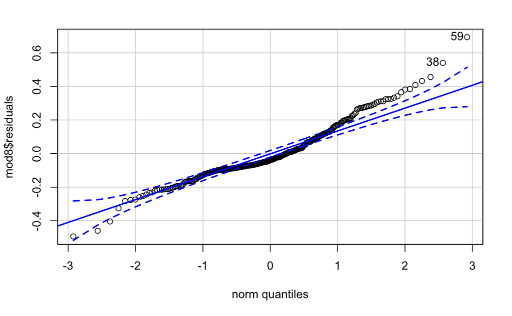

```r
qqPlot(mod8$residuals)
```

## Models using transformation 1, from project 1:

Optimer lambda således at residualerne fra modellen best fitter en normalfordeling.

#### Wind Speed and Wind Speed Squared

```r
trans1 <- function(lambda,y){
    y.l <- 1/lambda*log((y^lambda)/(1-y^lambda))
    return(y.l)}

## profile likelihood for lambda
lp.lambda1 <- function(lambda,y){
    mod <- lm(trans1(lambda,y)~data$ws30+I(data$ws30^2))
    length(y)/2*log(summary(mod)$sigma^2) - sum(log(abs(1/(y*(1 - y^lambda)))))
    }

#plot(seq(0.01,1,0.01), sapply(seq(0.01,1,0.01), lp.lambda1, y=data$pow.obs.norm))

(opt.lambda.trans1=optimize(lp.lambda1,c(0,1),y=data$pow.obs.norm))
```

```
$minimum
[1] 0.1998237

$objective
[1] -657.4075
```

```r
mod3=glm(trans1(opt.lambda.trans1$minimum,data$pow.obs.norm)~ ws30+I(data$ws30^2),family=gaussian,  data=data)
summary(mod3)
```

```
Call:
glm(formula = trans1(opt.lambda.trans1$minimum, data$pow.obs.norm) ~
    ws30 + I(data$ws30^2), family = gaussian, data = data)

Deviance Residuals:
     Min        1Q    Median        3Q       Max
-11.6017   -1.9124    0.0211    2.2034   14.8546

Coefficients:
                Estimate Std. Error t value Pr(>|t|)
(Intercept)    -7.144437   0.908806  -7.861 7.87e-14 ***
ws30            1.705880   0.170709   9.993  < 2e-16 ***
I(data$ws30^2) -0.032117   0.007025  -4.572 7.22e-06 ***
---
Signif. codes:  0 ‘***’ 0.001 ‘**’ 0.01 ‘*’ 0.05 ‘.’ 0.1 ‘ ’ 1

(Dispersion parameter for gaussian family taken to be 14.06702)

    Null deviance: 9773.8  on 287  degrees of freedom
Residual deviance: 4009.1  on 285  degrees of freedom
AIC: 1583.7

Number of Fisher Scoring iterations: 2
```

```r
AIC(mod3)
```

```
[1] 1583.717
```

```
[1]  59 248
```

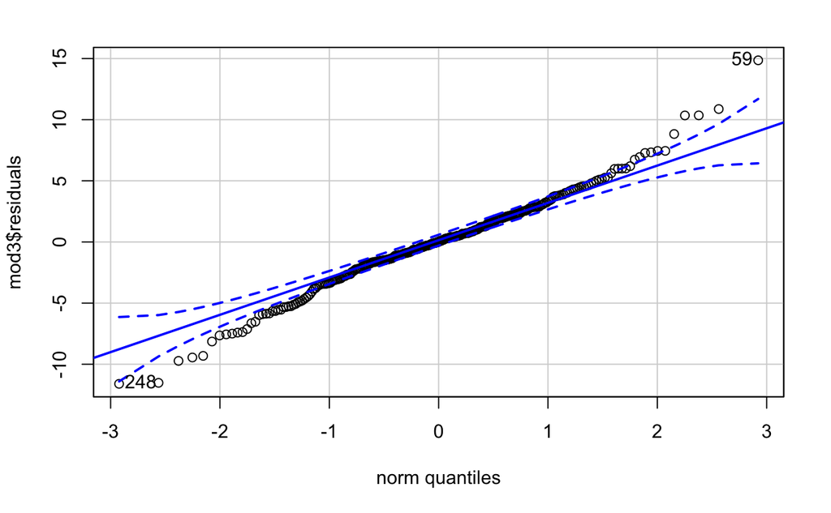

```r
qqPlot(mod3$residuals)
```

We have tried to add a third order term, but it did not improve the model as it was not significant.

#### Wind speed, Wind speed squared and cosine of wind direction

```r
#Forsøg med sin og cos til wd

trans1 <- function(lambda,y){
    y.l <- 1/lambda*log((y^lambda)/(1-y^lambda))
    return(y.l)}

## profile likelihood for lambda
lp.lambda1 <- function(lambda,y){
    mod <- lm(trans1(lambda,y)~data$ws30+I(data$ws30^2)+cos(data$wd30))
    length(y)/2*log(summary(mod)$sigma^2) - sum(log(abs(1/(y*(1 - y^lambda)))))
    }

(opt.lambda.trans1=optimize(lp.lambda1,c(0,1),y=data$pow.obs.norm))
```

```
$minimum
[1] 0.206883

$objective
[1] -662.0193
```

```r
library(car)
mod5=glm(trans1(opt.lambda.trans1$minimum,data$pow.obs.norm)~ data$ws30+I(data$ws30^2)+cos(data$wd30),family=gaussian,  data=data)
summary(mod5)
```

```
Call:
glm(formula = trans1(opt.lambda.trans1$minimum, data$pow.obs.norm) ~
    data$ws30 + I(data$ws30^2) + cos(data$wd30), family = gaussian,
    data = data)

Deviance Residuals:
     Min        1Q    Median        3Q       Max
-11.7027   -1.9832   -0.0276    2.0411   13.4645

Coefficients:
                Estimate Std. Error t value Pr(>|t|)
(Intercept)    -7.084076   0.870438  -8.139 1.27e-14 ***
data$ws30       1.634302   0.163594   9.990  < 2e-16 ***
I(data$ws30^2) -0.030139   0.006735  -4.475 1.11e-05 ***
cos(data$wd30) -0.995170   0.310225  -3.208  0.00149 **
---
Signif. codes:  0 ‘***’ 0.001 ‘**’ 0.01 ‘*’ 0.05 ‘.’ 0.1 ‘ ’ 1

(Dispersion parameter for gaussian family taken to be 12.87999)

    Null deviance: 9234.5  on 287  degrees of freedom
Residual deviance: 3657.9  on 284  degrees of freedom
AIC: 1559.3

Number of Fisher Scoring iterations: 2
```

```r
AIC(mod5)
```

```
[1] 1559.315
```

```
[1]  59 248
```

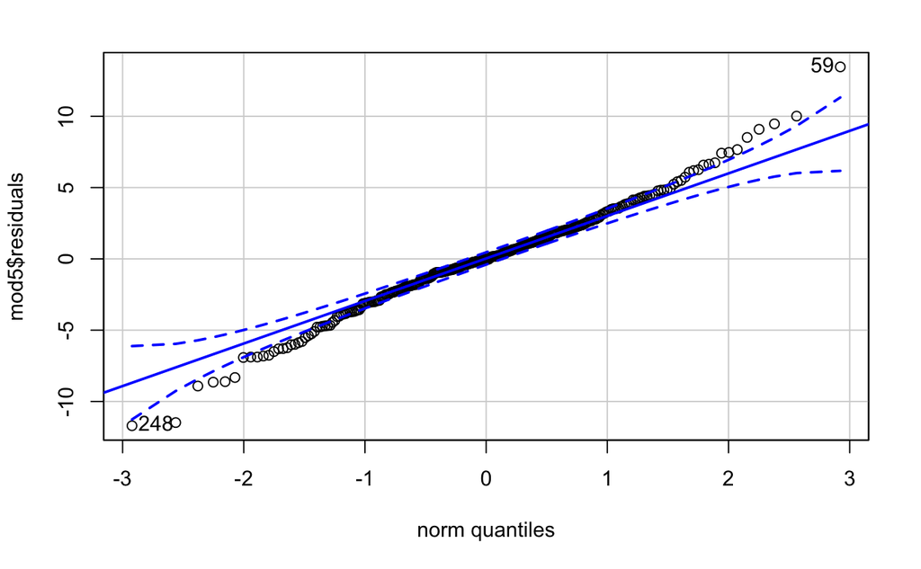

```r
qqPlot(mod5$residuals)
```

#### Wind speed, Wind speed squared and cosine of wind direction

```r
#Forsøg med sin og cos til wd

trans1 <- function(lambda,y){
    y.l <- 1/lambda*log((y^lambda)/(1-y^lambda))
    return(y.l)}

## profile likelihood for lambda
lp.lambda1 <- function(lambda,y){
    mod <- lm(trans1(lambda,y)~data$ws30+I(data$ws30^2)+cos(data$wd30))
    length(y)/2*log(summary(mod)$sigma^2) - sum(log(abs(1/(y*(1 - y^lambda)))))
    }

(opt.lambda.trans1=optimize(lp.lambda1,c(0,1),y=data$pow.obs.norm))
```

```
$minimum
[1] 0.206883

$objective
[1] -662.0193
```

```r
library(car)
mod6=glm(trans1(opt.lambda.trans1$minimum,data$pow.obs.norm)~data$ws30+I(data$ws30^2)+cos(data$wd30),family=gaussian,  data=data)
summary(mod6)
```

```
Call:
glm(formula = trans1(opt.lambda.trans1$minimum, data$pow.obs.norm) ~
    data$ws30 + I(data$ws30^2) + cos(data$wd30), family = gaussian,
    data = data)

Deviance Residuals:
     Min        1Q    Median        3Q       Max
-11.7027   -1.9832   -0.0276    2.0411   13.4645

Coefficients:
                Estimate Std. Error t value Pr(>|t|)
(Intercept)    -7.084076   0.870438  -8.139 1.27e-14 ***
data$ws30       1.634302   0.163594   9.990  < 2e-16 ***
I(data$ws30^2) -0.030139   0.006735  -4.475 1.11e-05 ***
cos(data$wd30) -0.995170   0.310225  -3.208  0.00149 **
---
Signif. codes:  0 ‘***’ 0.001 ‘**’ 0.01 ‘*’ 0.05 ‘.’ 0.1 ‘ ’ 1

(Dispersion parameter for gaussian family taken to be 12.87999)

    Null deviance: 9234.5  on 287  degrees of freedom
Residual deviance: 3657.9  on 284  degrees of freedom
AIC: 1559.3

Number of Fisher Scoring iterations: 2
```

```r
AIC(mod6)
```

```
[1] 1559.315
```

```
[1]  59 248
```

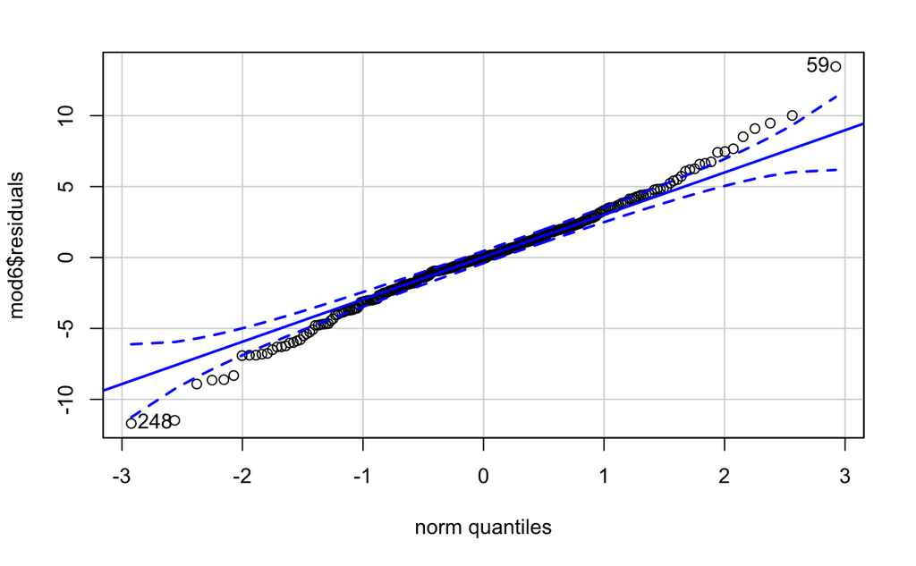

```r
qqPlot(mod6$residuals)
```

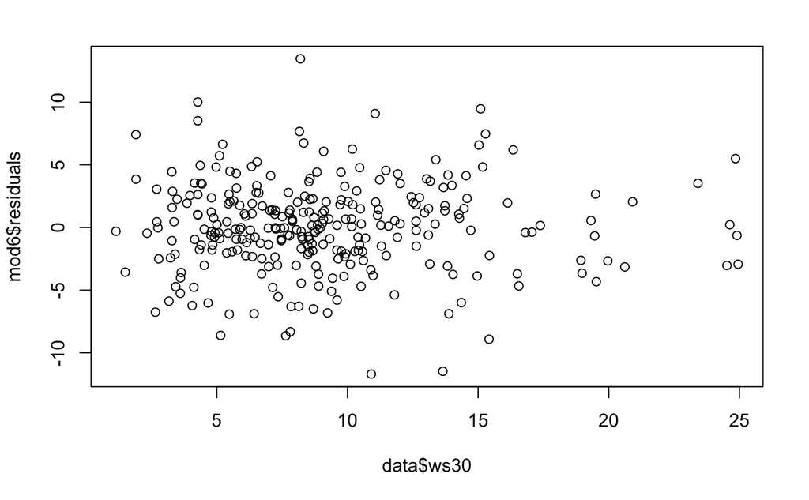

```r
plot(data$ws30,mod6$residuals)
```

### 3. Present the parameters of the final model, this include quantification of the uncertainty of parameters.

```r
Confint(mod6)
```

```
                  Estimate      2.5 %     97.5 %
(Intercept)    -7.08407594 -8.7901026 -5.3780493
data$ws30       1.63430162  1.3136635  1.9549398
I(data$ws30^2) -0.03013925 -0.0433396 -0.0169389
cos(data$wd30) -0.99516971 -1.6031986 -0.3871408
```

### 4. Give an interpretation of the parameters in the particular this should include presentation of any nonlinear functions (series expansions) of the exploratory variables.

Hvad gør de forskellige værdier for vore power production fx sin kan give noget svingning.

**cos(data$wd30)** Leddet påvirker power production negativt, derfor har den størst positivt bidrag når den er lig -1. Cosinus til $\pi$ er lig -1, det vil sige, at vi får mest ud af wind direction, når vinden kommer med en vinkel på 180 grader.

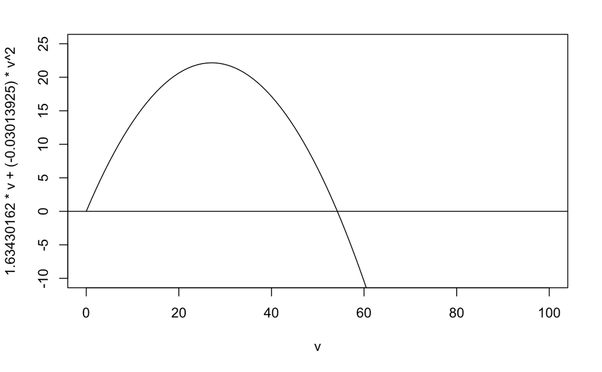

```r
v=0:100
plot(v, 1.63430162*v+(-0.03013925)*v^2, type="l", ylim=c(-10,25))
abline(h=0)
```

### 5. Present the final model e.g. some graphical presentation of predictions under different scenarios of wind speed and wind direction.

```r
# Function to plot the prediction result of regression model based on wind speed.
predictRegression.windSpeed <- function(x1.pred, x2, y, modelRegression, name){
      dataFramePredict <- data.frame(x1 = x1.pred, x2 = rep(mean(x2), length(x1.pred)))
      # Calculate predictions and intervals
      valuePred <- predict.lm(modelRegression, dataFramePredict, se.fit = TRUE)
      intervalPred <- predict.lm(modelRegression, newdata = dataFramePredict, interval = "pred", level = 0.95)
      intervalConf <- predict.lm(modelRegression, newdata = dataFramePredict, interval = "conf", level = 0.95)
     # plot
      plot(dataFramePredict$x1, valuePred$fit, pch = 20, ylim = c(min(y, intervalPred), max(y, intervalPred)), xlim = c(min(x1, dataFramePredict$x1), max(x1, dataFramePredict$x1)), xlab = name, ylab = 'Transformed, Normalized Power Production')
      matlines(dataFramePredict$x1, intervalPred, lty = c(1, 2, 2), col = c("black", "blue", "blue"), lwd = 2)
      points(x1, y)  # Transformed observations
      lines(dataFramePredict$x1, intervalConf[, 2], lty = 3, col = "red", lwd = 2)
      lines(dataFramePredict$x1, intervalConf[, 3], lty = 3, col = "red", lwd = 2)
      legend("bottomright", inset = .02, legend = c("Regression Curve", "Prediction Interval", "Confidence Intercal"), col = c("black", "blue", "red"), lty = c(1, 2, 3), lwd = c(2, 2, 2), cex = 0.8)
}
```

```
Assuming constant prediction variance even though model fit is weighted
```

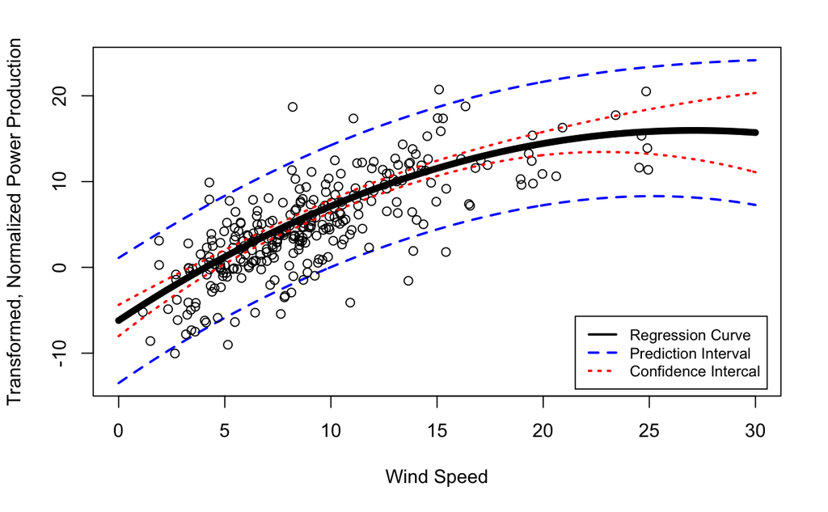

```r
x1.pred <- seq(0, 30, 0.1)
x1 = data$ws30
x2 =data$wd30
y = trans1(opt.lambda.trans1$minimum,data$pow.obs.norm)
fittrans1 = glm(y ~ 1 + x1 + I(x1^2) + cos(x2))
predictRegression.windSpeed(x1.pred, x2, y, fittrans1, "Wind Speed")
```

```
Assuming constant prediction variance even though model fit is weighted
```

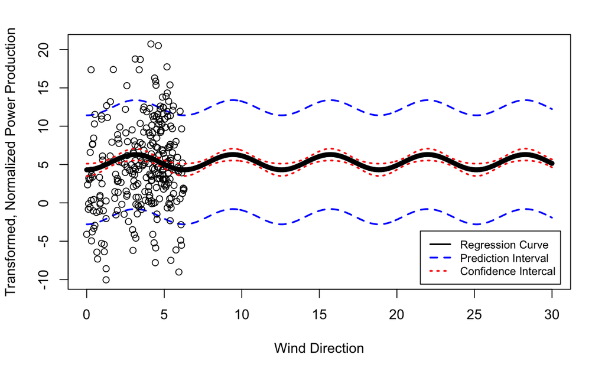

```r
x1.pred <- seq(0, 30, 0.1)
x2 = data$ws30
x1 =data$wd30
y = trans1(opt.lambda.trans1$minimum,data$pow.obs.norm)
fittrans1 = glm(y ~ 1 + x2 + I(x2^2) + cos(x1))
predictRegression.windSpeed(x1.pred, x2, y, fittrans1,"Wind Direction")
```

```r
plot(trans1(opt.lambda.trans1$minimum,data$pow.obs.norm))
points(mod6$fitted.values, pch=16, col="Red")

#lines(interval_l, col)
```

[output not shown]

Holder wind direction mod trans data sæt en værdi ind for wind direction.

```r
plot(trans1(opt.lambda.trans1$minimum,data$pow.obs.norm))
```

[output not shown]